# STA 141A Course Project

Han Truong

2024-03-13

## Abstract

Recent studies delve into the neural underpinnings of how mice make decisions through utilizing visual stimuli and neural recordings. Our of the goals of quantitative neuroscience is to develop predictive models that establish the relationship between the sensory streams with neuron firing. This aims to explore the neural dynamics during decision-making tasks, shedding light on the neuronal correlates of visual processing and choice behavior in mice. By pinpointing neural signatures associated with varying stimuli, the findings ultimately contribute to a deeper understanding of cognitive processes in decision-making in mice.

## Introduction

Progress in measurement techniques and analysis allow us to access the neural activity in brain areas that could transform sensory input into behavior. The study conducted by Steinmetz et al.(2019) provides an in-depth look into the neural activity during visual decision-making tasks in mice. By focusing on the spike trains recorded from the visual cortex of mice, we aim to develop a model capable of forecasting behavioral responses based on neural activity. Through the integration of experimental approaches, we deepen our understanding of the neural basis of behavior.

## i. Data structures across sessions

We were given a total of 18 RDS files documenting the 18 sessions of experiments performed on the following 4 mice.

```
## [1] "Cori"
## [1] "2016-12-14"
## [1] "Cori"
## [1] "2016-12-17"
## [1] "Cori"
## [1] "2016-12-18"
## [1] "Forssmann"
## [1] "2017-11-01"
## [1] "Forssmann"
## [1] "2017-11-02"
## [1] "Forssmann"
## [1] "2017-11-04"
## [1] "Forssmann"
## [1] "2017-11-05"
## [1] "Hench"
```

[output cut: 21 more lines]

- `feedback_type`: indicator for feedback success (1 for success, -1 for failure)
- `contrast_left`: contrast of the left stimulus
- `constrast_right`: contrast of the right stimulus
- `mouse_name`: influenced by four factors
- `time`: vector of dimension across sessions for number of trials
- `spks`: matrix of dimensions across session *i* for number of trials
- `date_exp`: date that the experiment was performed and recorded
- `brain_area`: area of the brain where each neuron live

```
## [1] "contrast_left"  "contrast_right" "feedback_type"  "mouse_name"
## [5] "brain_area"     "date_exp"       "spks"           "time"
```

```
##                Length Class  Mode
## contrast_left  228    -none- numeric
## contrast_right 228    -none- numeric
## feedback_type  228    -none- numeric
## mouse_name       1    -none- character
## brain_area     619    -none- character
## date_exp         1    -none- character
## spks           228    -none- list
## time           228    -none- list
```

```
## [1] 619  40
```

```
## [1] 619
```

```
##  [1] "DG"    "VISam" "MG"    "CA1"   "SPF"   "root"  "LP"    "MRN"   "POST"
## [10] "NB"    "VISp"
```

```
## [1] 228
```

```
##  [1] 0 0 0 0 0 0 0 0 0 0 0 0 0 0 0 0 0 0 0 0 0 0 0 0 0 0 0 0 0 0 0 0 0 0 0 0 0 0
## [39] 0 0
```

```
## [1] 0.6622807
```

```
## [1] 11
```

Analyzing the success rate provides us insights into the overall performance of the experimental setup. The success rate based on feedback type is a relevant feature for predicting outcomes. Later on, by comparing the model’s predictions with the actual success rate, we can assess the model’s accuracy. ATo calculate the feedback type, the number of successful trials (trials where the feedback type is 1) is divided by the total number of trials to get the probability of success for each session. For example here the probability of success of trials in session 3 is 66.2%.

We find that there are 11 areas of the brain being stimulated in session 3. Knowing the unique brain areas allow us to create features based on these areas. For example, I want to include features related to the activity of specific brain areas in my predictive model.

## ii. Neural activities during each trial

Now, we connect the neuron spikes to the brain area in each trial. We will use the activities in Session 3 Trial 5 for our analysis.

```
## # A tibble: 11 × 2
##    area   mean
##    <chr> <dbl>
##  1 CA1   1.79
##  2 DG    3.32
##  3 LP    2
##  4 MG    2.44
##  5 MRN   6.10
##  6 NB    1.88
##  7 POST  0.667
##  8 SPF   3.67
##  9 VISam 1.82
## 10 VISp  0.868
## 11 root  1.75
```

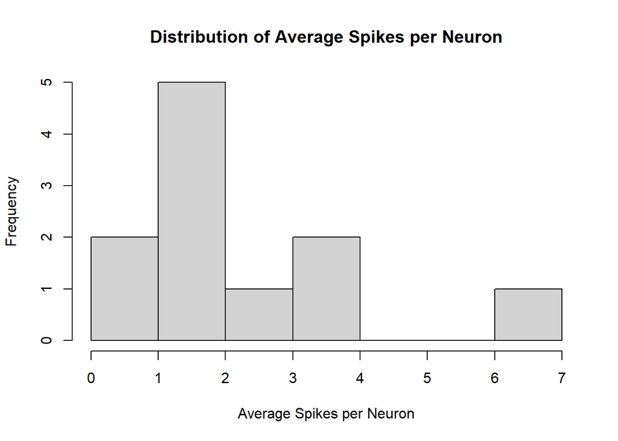

From our results, the brain areas with the higher average spikes per neuron are MRN and SPF, which may indicate higher neuronal activity to stimuli in these areas. The distribution of the average spikes per neuron from the histogram appears to be right-skewed, implying some brain areas having higher average values compared to others. Brain areas with higher average spikes per neuron, in this case MRN and SPF, may play a more significant role in decision-making tasks in mice.

## Data Processing

```
##  feedback_type decision   avg_spikes
##  -1: 77        1:46     Min.   :1.746
##  1 :151        2:84     1st Qu.:2.043
##                3:76     Median :2.209
##                4:22     Mean   :2.234
##                         3rd Qu.:2.422
##                         Max.   :2.847
```

The average spikes was calculated to be around 2.232, re-enforcing our finding that brain areas like MRN and SPF with average spikes 5.63 and 4.8 to have very high neuronal activity response to stimuli.

```
## # A tibble: 11 × 8
##    brain_area region_sum_spike region_count region_mean_spike trial_id
##    <chr>                 <dbl>        <int>             <dbl>    <dbl>
##  1 CA1                      92           42              2.19        5
##  2 DG                      108           34              3.18        5
##  3 LP                       15            4              3.75        5
##  4 MG                      361          137              2.64        5
##  5 MRN                     231           41              5.63        5
##  6 NB                      106           43              2.47        5
##  7 POST                     83           63              1.32        5
##  8 SPF                      72           15              4.8         5
##  9 VISam                   268          114              2.35        5
## 10 VISp                    143          114              1.25        5
## 11 root                     16           12              1.33        5
## # ℹ 3 more variables: contrast_left <dbl>, contrast_right <dbl>,
## #   feedback_type <dbl>
```

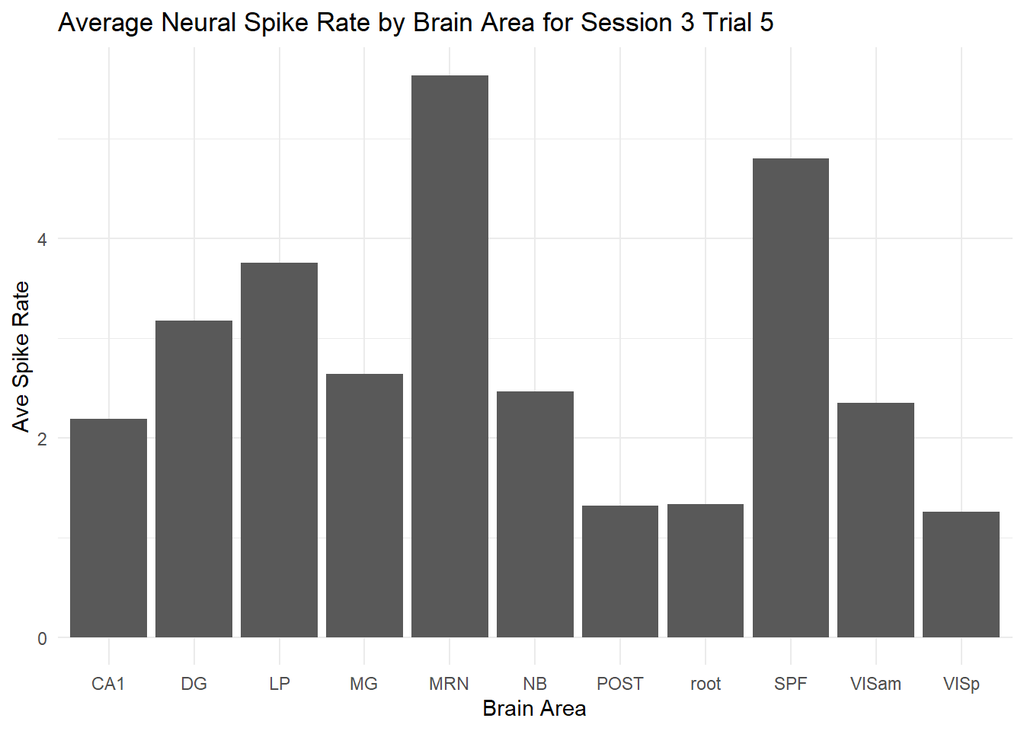

Before feeding the data into the model, it’s important to preprocess the data and structure it into the format that can be used for modeling. The plot displays the regions of interest within the mice’ visual cortex and the average spike rate of neurons within each brain area. The higher spike rates in MRN and SPF suggest increased neuronal activity, which corresponds to the heightened responsiveness to decision-making processes.

```
## # A tibble: 6 × 11
##   brain_area region_sum_spike region_count region_mean_spike trial_id
##   <chr>                 <dbl>        <int>             <dbl>    <int>
## 1 CA1                     115           42              2.74        1
## 2 DG                      138           34              4.06        1
## 3 LP                       18            4              4.5         1
## 4 MG                      373          137              2.72        1
## 5 MRN                     231           41              5.63        1
## 6 NB                       72           43              1.67        1
## # ℹ 6 more variables: contrast_left <dbl>, contrast_right <dbl>,
## #   feedback_type <dbl>, mouse_name <chr>, date_exp <chr>, session_id <dbl>
```

Here, the `session_data` function was created to facilitate the retrieval and processing of data for individual session. We do this to ensure that the data is organized and structured for subsequent analysis and modeling. The table here shows the sum number of spikes and the mean number of spikes for each brain area in session 3. We can see `contrast_left` is 0.5 while all `contrast_righ`t is 0, which indicates activity in contrast left part of each brain areas contribute most to the spike activity.

Here, `trial_functional_data` was created to process data for a single trial within a session. It will calculate the average spike counts across all neurons for each time bin. Then, the `session_functional_data` was created to process data for an entire session by iterating through all of the trials. We break down the data processing tasks into 2 smaller functions to be reused across multiple sessions and trials without the need to duplicate code.

```
## # A tibble: 6 × 49
##     bin1   bin2   bin3   bin4   bin5   bin6   bin7   bin8   bin9  bin10  bin11
##    <dbl>  <dbl>  <dbl>  <dbl>  <dbl>  <dbl>  <dbl>  <dbl>  <dbl>  <dbl>  <dbl>
## 1 0.0490 0.0368 0.0177 0.0150 0.0327 0.0286 0.0313 0.0123 0.0341 0.0191 0.0463
## 2 0.0300 0.0313 0.0341 0.0272 0.0259 0.0313 0.0218 0.0232 0.0232 0.0341 0.0272
## 3 0.0490 0.0504 0.0300 0.0436 0.0245 0.0409 0.0300 0.0381 0.0341 0.0422 0.0559
## 4 0.0559 0.0531 0.0272 0.0613 0.0572 0.0599 0.0450 0.0286 0.0395 0.0354 0.0368
## 5 0.0272 0.0436 0.0313 0.0245 0.0450 0.0381 0.0463 0.0572 0.0477 0.0163 0.0272
## 6 0.0490 0.0218 0.0163 0.0109 0.0123 0.0232 0.0272 0.0327 0.0163 0.0191 0.0300
## # ℹ 38 more variables: bin12 <dbl>, bin13 <dbl>, bin14 <dbl>, bin15 <dbl>,
## #   bin16 <dbl>, bin17 <dbl>, bin18 <dbl>, bin19 <dbl>, bin20 <dbl>,
## #   bin21 <dbl>, bin22 <dbl>, bin23 <dbl>, bin24 <dbl>, bin25 <dbl>,
## #   bin26 <dbl>, bin27 <dbl>, bin28 <dbl>, bin29 <dbl>, bin30 <dbl>,
## #   bin31 <dbl>, bin32 <dbl>, bin33 <dbl>, bin34 <dbl>, bin35 <dbl>,
## #   bin36 <dbl>, bin37 <dbl>, bin38 <dbl>, bin39 <dbl>, bin40 <dbl>,
## #   trial_id <int>, contrast_left <dbl>, contrast_right <dbl>, …
```

Our data from multiple sessions were combined into a single data frame `full_functional_tibble` to be used to develop models in predicting neuronal responses to stimuli and trial success. We can also use this to compare outcomes between different sessions to identify differences in neural responses under various conditions.

```
## # A tibble: 18 × 2
##    session_id `sum(region_count)`
##         <int>               <int>
##  1          1                 734
##  2          2                1070
##  3          3                 619
##  4          4                1769
##  5          5                1077
##  6          6                1169
##  7          7                 584
##  8          8                1157
##  9          9                 788
## 10         10                1172
## 11         11                 857
## 12         12                 698
## 13         13                 983
## 14         14                 756
## 15         15                 743
## 16         16                 474
## 17         17                 565
## 18         18                1090
```

```
## # A tibble: 18 × 2
##    session_id unique_area
##         <int>       <int>
##  1          1           8
##  2          2           5
##  3          3          11
##  4          4          11
##  5          5          10
##  6          6           5
##  7          7           8
##  8          8          15
##  9          9          12
## 10         10          13
## 11         11           6
## 12         12          12
## 13         13          15
## 14         14          10
## 15         15           8
## 16         16           6
## 17         17           6
## 18         18          10
```

```
## # A tibble: 18 × 2
##    session_id mean_session_spike
##         <int>              <dbl>
##  1          1              1.54
##  2          2              1.27
##  3          3              2.23
##  4          4              0.842
##  5          5              1.12
##  6          6              0.663
##  7          7              1.42
##  8          8              1.66
##  9          9              1.59
## 10         10              1.19
## 11         11              1.25
## 12         12              1.66
## 13         13              2.46
## 14         14              1.01
## 15         15              1.46
## 16         16              1.05
## 17         17              1.17
## 18         18              1.10
```

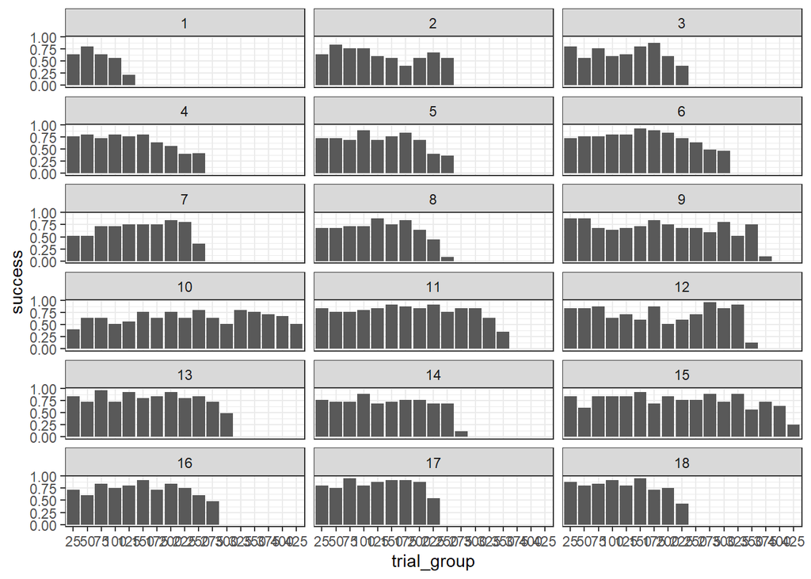

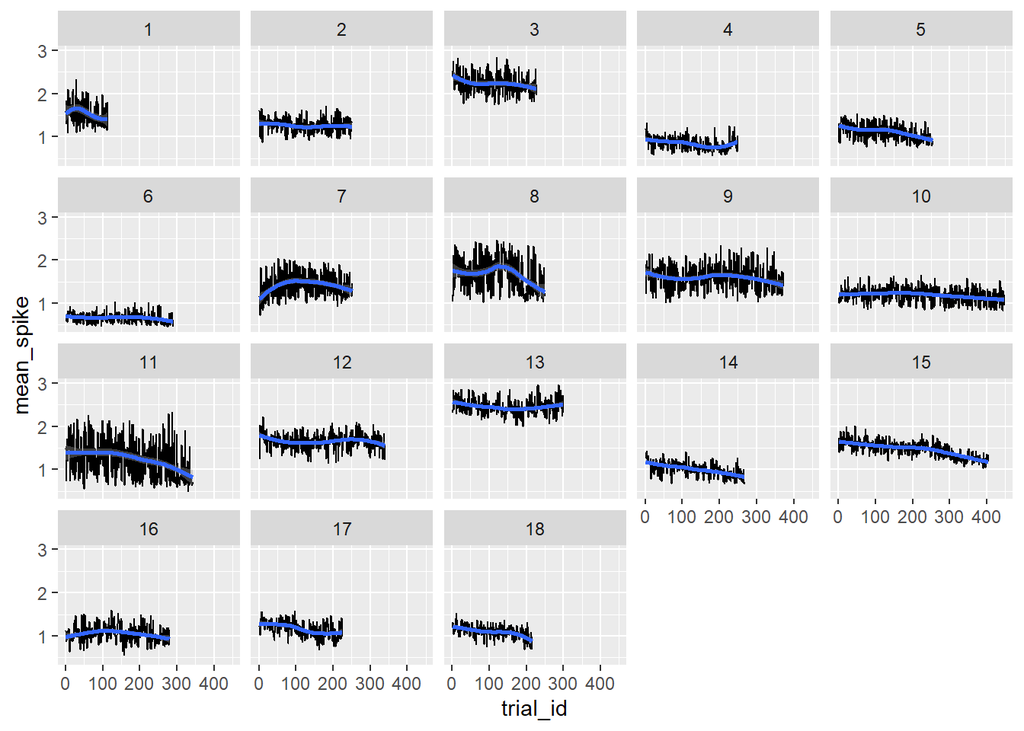

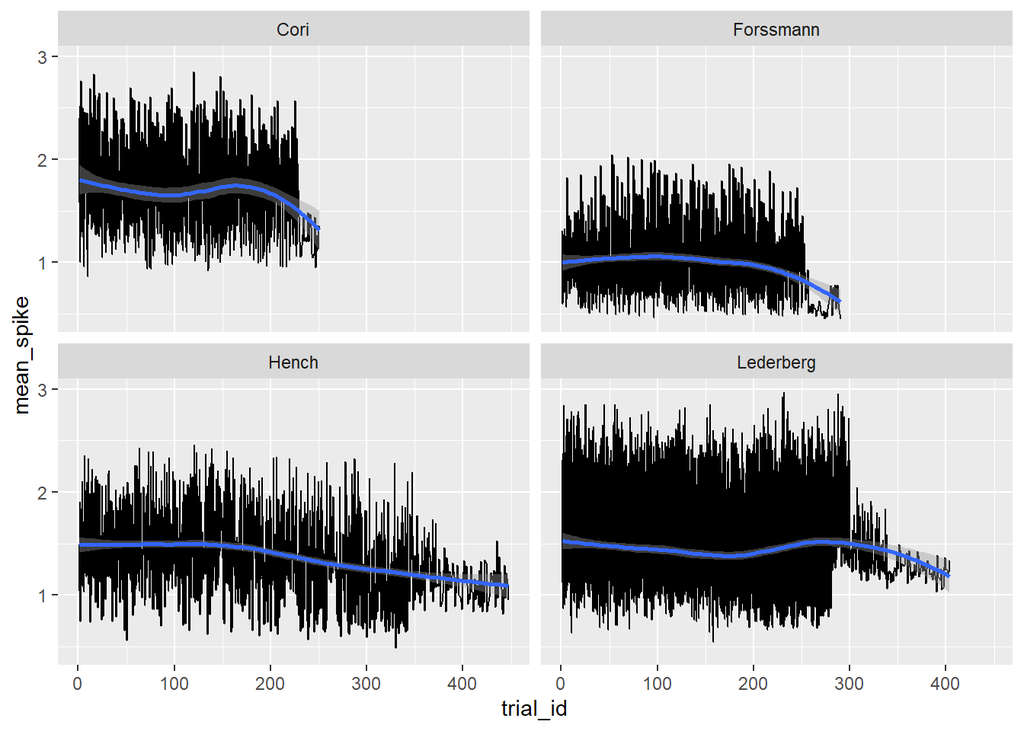

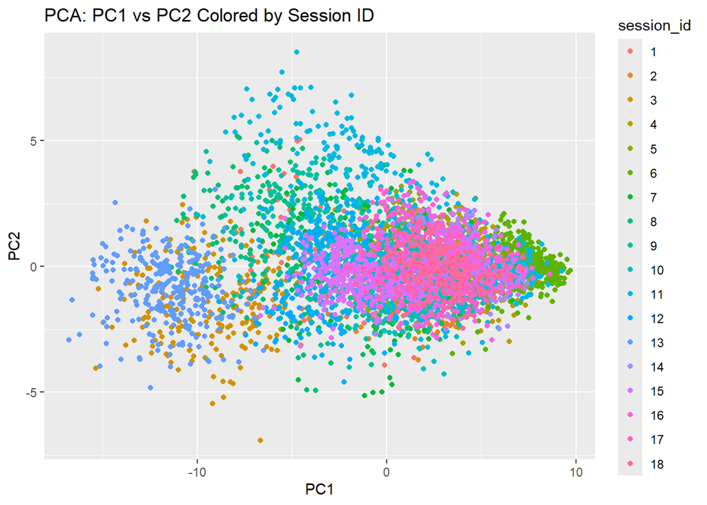

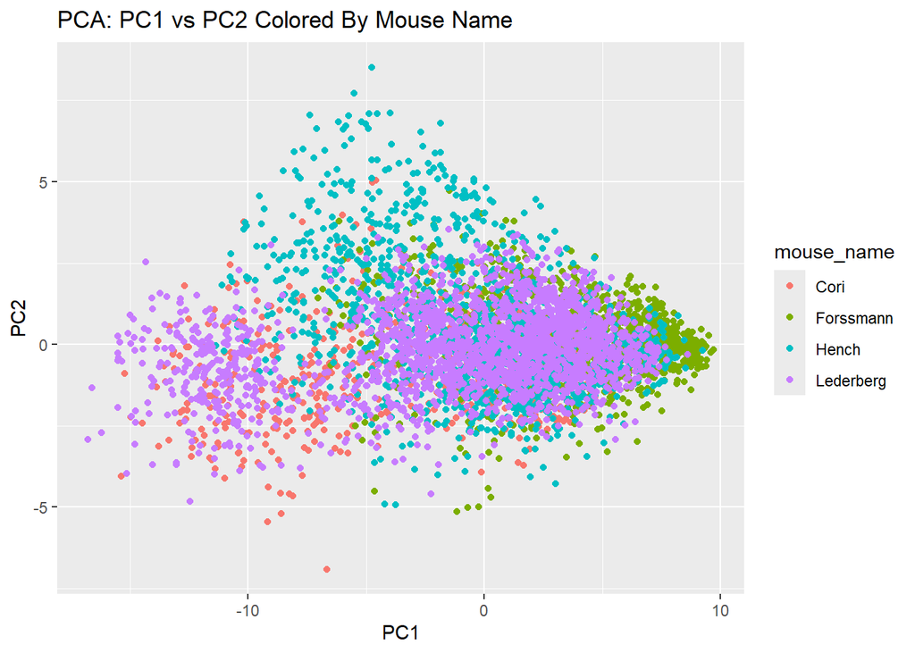

This scatter plot exhibits how different mice are distributed in a reduced-dimensional space. Each point corresponds to the mouse name. Through these 2 plots, we can see the neuronal activities of Lederberg correlates with Session 13 negatively and with Sessions 14-15 around the PC1 = 0.

## Data Integration

```
## # A tibble: 6 × 45
##   session_id trial_id contrast_right contrast_left contrast_diff   bin1   bin2
##   <fct>         <int>          <dbl>         <dbl>         <dbl>  <dbl>  <dbl>
## 1 1                 1            0.5           0             0.5 0.0490 0.0368
## 2 1                 2            0             0             0   0.0300 0.0313
## 3 1                 3            1             0.5           0.5 0.0490 0.0504
## 4 1                 4            0             0             0   0.0559 0.0531
## 5 1                 5            0             0             0   0.0272 0.0436
## 6 1                 6            0             0             0   0.0490 0.0218
## # ℹ 38 more variables: bin3 <dbl>, bin4 <dbl>, bin5 <dbl>, bin6 <dbl>,
## #   bin7 <dbl>, bin8 <dbl>, bin9 <dbl>, bin10 <dbl>, bin11 <dbl>, bin12 <dbl>,
## #   bin13 <dbl>, bin14 <dbl>, bin15 <dbl>, bin16 <dbl>, bin17 <dbl>,
## #   bin18 <dbl>, bin19 <dbl>, bin20 <dbl>, bin21 <dbl>, bin22 <dbl>,
## #   bin23 <dbl>, bin24 <dbl>, bin25 <dbl>, bin26 <dbl>, bin27 <dbl>,
## #   bin28 <dbl>, bin29 <dbl>, bin30 <dbl>, bin31 <dbl>, bin32 <dbl>,
## #   bin33 <dbl>, bin34 <dbl>, bin35 <dbl>, bin36 <dbl>, bin37 <dbl>, …
```

Here, we prepare the data for predictive modeling by selecting relevant predictors and creating a design matrix that is suitable for modeling.

## Predictive Modeling

In this section, we will try to predict what the mice perceive based on the neuron data, then compare these results to the contrast values to predict the feedback type. I have decided to use the XGBoost model since it is highly scalable and can efficiently handle large data sets.

[output not shown]

```
## [1] "Accuracy: 0.723425196850394"
```

```
## Confusion Matrix and Statistics
##
##           Reference
## Prediction   0   1
##          0  87  71
##          1 210 648
##
##                Accuracy : 0.7234
##                  95% CI : (0.6948, 0.7507)
##     No Information Rate : 0.7077
##     P-Value [Acc > NIR] : 0.1423
##
##                   Kappa : 0.2251
##
##  Mcnemar's Test P-Value : <2e-16
##
##             Sensitivity : 0.29293
##             Specificity : 0.90125
##          Pos Pred Value : 0.55063
##          Neg Pred Value : 0.75524
##              Prevalence : 0.29232
##          Detection Rate : 0.08563
##    Detection Prevalence : 0.15551
##       Balanced Accuracy : 0.59709
##
##        'Positive' Class : 0
##
```

```
## [1] "AUROC: 0.727427262893188"
```

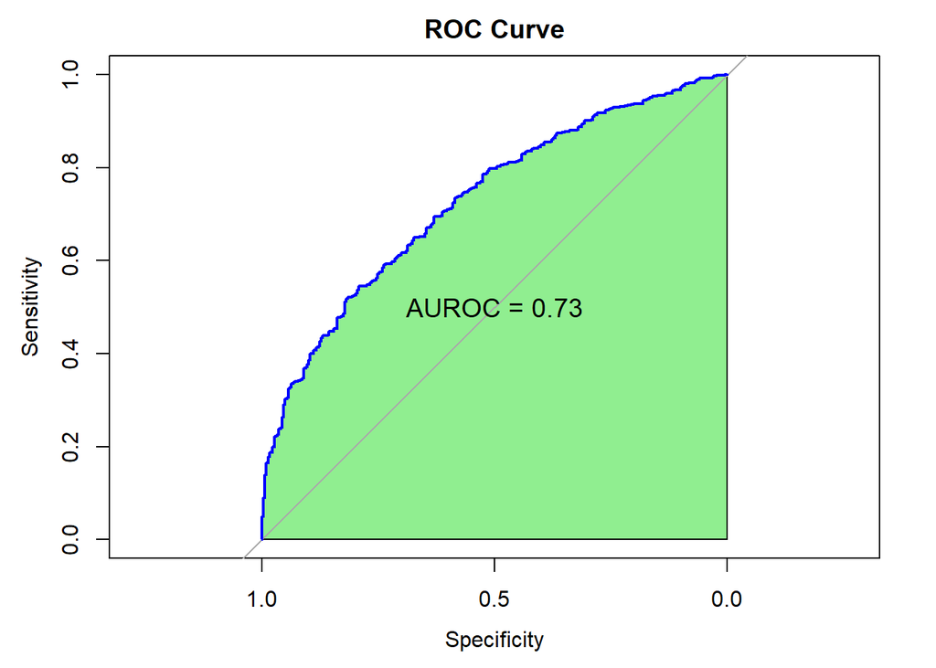

## Prediction Performance on Test Sets

After the test data were posted, I incorporated them to my already formed model to ensure that everything is processed properly.

```
## [1] "Session 1 accuracy: 0.96"
```

```
## Confusion Matrix and Statistics
##
##           Reference
## Prediction  0  1
##          0 16  0
##          1  2 32
##
##                Accuracy : 0.96
##                  95% CI : (0.8629, 0.9951)
##     No Information Rate : 0.64
##     P-Value [Acc > NIR] : 8.489e-08
##
##                   Kappa : 0.911
##
##  Mcnemar's Test P-Value : 0.4795
##
##             Sensitivity : 0.8889
##             Specificity : 1.0000
##          Pos Pred Value : 1.0000
##          Neg Pred Value : 0.9412
##              Prevalence : 0.3600
##          Detection Rate : 0.3200
##    Detection Prevalence : 0.3200
##       Balanced Accuracy : 0.9444
##
##        'Positive' Class : 0
##
```

```
## Area under the curve: 0.9965
```

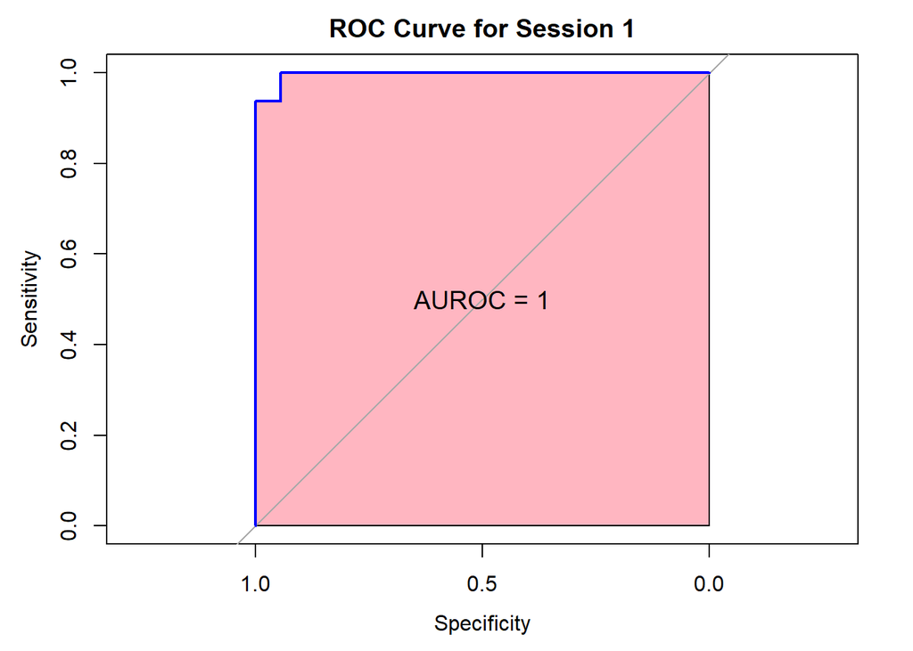

```
## [1] "Session 18 accuracy: 0.96"
```

```
## Confusion Matrix and Statistics
##
##           Reference
## Prediction  0  1
##          0  9  1
##          1  1 39
##
##                Accuracy : 0.96
##                  95% CI : (0.8629, 0.9951)
##     No Information Rate : 0.8
##     P-Value [Acc > NIR] : 0.001285
##
##                   Kappa : 0.875
##
##  Mcnemar's Test P-Value : 1.000000
##
##             Sensitivity : 0.9000
##             Specificity : 0.9750
##          Pos Pred Value : 0.9000
##          Neg Pred Value : 0.9750
##              Prevalence : 0.2000
##          Detection Rate : 0.1800
##    Detection Prevalence : 0.2000
##       Balanced Accuracy : 0.9375
##
##        'Positive' Class : 0
##
```

```
## Area under the curve: 0.985
```

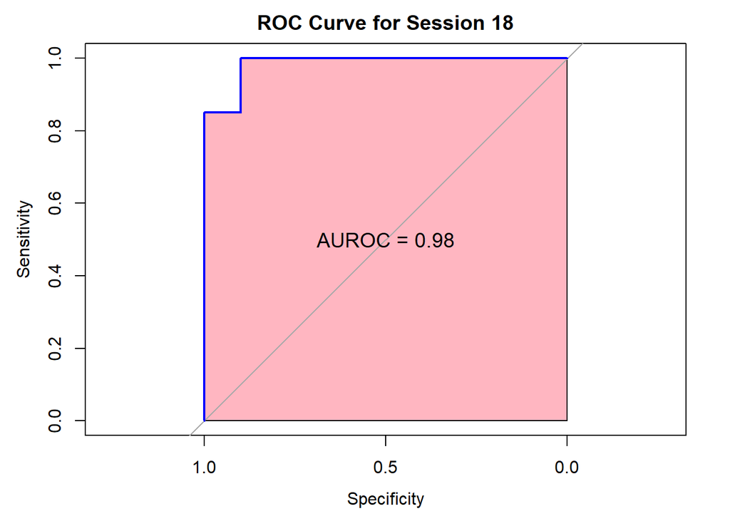

## Work Cited

I used Chat GPT to help with understanding how some of the R functions work. For example, I used it to convert existing data frames to generate a `tibbles` containing data for a specific trial within a session, and calculate the success rate based on feedback type in the data set store in `session`.

Chat GPT was also used to aid me in analysis in this project. I used it to help understand how to use AUC, ROC curves, and accuracy measures to evaluate my model, write the introduction, and understand the necessary steps needed to process data and perform EDA tasks.

The codes conducting by the TAs in classes and discussions were used as baseline in this project. Changes were made to these codes to adapt better into my own unique project.

## References

https://www.ncbi.nlm.nih.gov/pmc/articles/PMC4970242/ https://www.ncbi.nlm.nih.gov/pmc/articles/PMC7548699/ https://developers.google.com/machine-learning/crash-course/classification/roc-and-auc#:~:text=An%20ROC%20curve%20(receiver%20operating,False%20Positive%20Rate